# Categorical Data Analysis

Michael Liou

2022-07-05

# Overview

This is a very broad area, but I feel like it’s also super confusing because it’s all very confouded in terms of all the chisq tests that are scattered throughout the place. I’m trying to organize everything for myself here.

- CMH test
- score test for table
- Pearson
- Yates (continuity correction of Pearson)
- Barnard test (based on fixing 1 margin)
- fisher exact (based on fixing all margins)
- McNemar Test

# 2x2 sampling mechanisms

The many different sampling mechanisms arise from different study designs, and are critical to the assumptions of the population you are studying.

In an epidemiological context, the data is given as

|  | disease | no disease |  |
| --- | --- | --- | --- |
| exposure | a | b | n1 |
| no exposure | c | d | n0 |
|  | m1 | m0 | N |

- Poisson (nothing fixed)
- Multinomial (N) is fixed
  - “Cross Sectional” studies
- Two-sample Binomial (1 margin fixed)
  - “Cohort Study” = n1, n0 fixed
  - “Case Control Study” = m1, m0 fixed
    - a type of “retrospective” study.

## Hypergeometric (2 margins fixed)

## Poisson (cell means)

```r
# Independent Poisson

#' When specifying the mean, they can be specified cellwise, or by table, grouped by the nrow*ncol, in order of the columns
#'
#' @param mean means of the cells. If 1 number, all cells will have same
#'
#' @return
#' @export
#'
#' @examples
rpoisson_table <- function(num_tables = 1, mean = 5, nrow = 2,  ncol = 2) {
  cells <- rpois(ncol * nrow * num_tables, lambda = mean)
  vec_table <- split(cells, gl(num_tables, ncol*nrow))
  vapply(vec_table, matrix, nrow = nrow, ncol = ncol, byrow = FALSE, FUN.VALUE = matrix(1:(ncol*nrow), nrow = nrow))
}
```

```r
# 2x2 examples
poisson_table_examples <- rpoisson_table(5, mean = 5, nrow = 2, ncol = 2)
apply(poisson_table_examples,
      MARGIN = 3,
      FUN = addmargins,
      simplify = FALSE)
```

```
## $`1`
##          Sum
##     5  5  10
##     2  5   7
## Sum 7 10  17
##
## $`2`
##          Sum
##     3  6   9
##     3  5   8
## Sum 6 11  17
##
## $`3`
##           Sum
##     10  5  15
##      3  9  12
## Sum 13 14  27
##
## $`4`
##          Sum
##     6  8  14
##     3  3   6
## Sum 9 11  20
##
## $`5`
##          Sum
##      9 3  12
##      5 3   8
## Sum 14 6  20
```

## Multinomial (Grand Total Fixed)

```r
# grand total fixed
rmultinom_table <- function(num_tables = 1, N = 20, nrow = 2, ncol = 2, p = c(1, 1, 1, 1)) {
  stopifnot(length(p) == nrow * ncol)
  # p is internally standardized by rmultinom
  cells <- rmultinom(num_tables, N, p)
  dim(cells) <- c(nrow, ncol, num_tables)
  cells
}
```

```r
# examples
multinom_table_examples <- rmultinom_table(5, N = 20, nrow = 2, ncol = 2, p = c(1, 1, 1, 1))
apply(multinom_table_examples,
      MARGIN = 3,
      FUN = addmargins,
      simplify = FALSE)
```

```
## [[1]]
##          Sum
##      6 4  10
##      5 5  10
## Sum 11 9  20
##
## [[2]]
##           Sum
##      6  4  10
##      4  6  10
## Sum 10 10  20
##
## [[3]]
##           Sum
##      6  1   7
##      4  9  13
## Sum 10 10  20
##
## [[4]]
##          Sum
##      3 5   8
##      8 4  12
## Sum 11 9  20
##
## [[5]]
##          Sum
##      4 6  10
##      7 3  10
## Sum 11 9  20
```

## Binomial Two Sample (One fixed margin)

```r
# Sample a 2x2 table
rbinom_table <- function(num_tables = 1, row_n = c(10, 10), p = c(.5, .5)) {
  vapply(1:num_tables,
       FUN = function(x) {
         a <- rbinom(length(row_n), row_n, p) # fix margins
         binom_table <- cbind(a, b = row_n-a) # make other column by subtraction and combine
         colnames(binom_table) <- NULL
         binom_table},
       FUN.VALUE = matrix(rep(1.1, 4), nrow =2)) # expected 2x2 table
}
```

```r
binom_table_examples <- rbinom_table(5, row_n = c(10, 10), p = c(.5, .5))
apply(binom_table_examples,
      MARGIN = 3,
      FUN = addmargins,
      simplify = FALSE)
```

```
## [[1]]
##          Sum
##     4  6  10
##     3  7  10
## Sum 7 13  20
##
## [[2]]
##           Sum
##      5  5  10
##      5  5  10
## Sum 10 10  20
##
## [[3]]
##           Sum
##      6  4  10
##      4  6  10
## Sum 10 10  20
##
## [[4]]
##          Sum
##      5 5  10
##      7 3  10
## Sum 12 8  20
##
## [[5]]
##          Sum
##      6 4  10
##      5 5  10
## Sum 11 9  20
```

## Hypergeometric

```r
# Fixed margins
# one hypergeometrical deviate will determine the entire table.
# only doing 2x2 tables with sampling method

rhyper_table <- function(num_tables, row_n = c(10, 10), col_n = c(10, 10))  {
  a <- rhyper(num_tables, row_n[1], row_n[2], col_n[1])
  vapply(a,
       FUN = function(x) {
         col1 <- c(x, col_n[1] - x)
         col2 <- row_n - col1
         contingency_table <- cbind(col1, col2)
         colnames(contingency_table) <- NULL # get rid of column names
         contingency_table
       },
       FUN.VALUE = matrix(c(0, 0, 0, 1.1), nrow = 2))}
```

```r
# examples
hyper_table_examples <- rhyper_table(num_tables = 5, row_n = c(10, 10), col_n = c(10, 10))
apply(hyper_table_examples,
      MARGIN = 3,
      FUN = addmargins,
      simplify = FALSE)
```

```
## [[1]]
##           Sum
##      4  6  10
##      6  4  10
## Sum 10 10  20
##
## [[2]]
##           Sum
##      5  5  10
##      5  5  10
## Sum 10 10  20
##
## [[3]]
##           Sum
##      5  5  10
##      5  5  10
## Sum 10 10  20
##
## [[4]]
##           Sum
##      4  6  10
##      6  4  10
## Sum 10 10  20
##
## [[5]]
##           Sum
##      4  6  10
##      6  4  10
## Sum 10 10  20
```

# Measures of Association

Given tables, it’s important to distinguish the properties of how to make comparisons, and summarize the information given. When dealing with percentages and ratios, it’s sometimes difficult to have an intuitive understanding of meaning on the percentage scale. The example Professor Guanhua Chen gives to stimulate you for this thinking is from [cartalk](https://www.cartalk.com/radio/puzzler/porch-potatoes):

> RAY: Potatoes are 99 percent water and one percent what? Potato. So say you take a bunch of potatoes, like 100 pounds of potatoes and you set them out on your back porch to dry out. TOM: Yeah, when they are dry they should weigh about a pound. RAY: Well, we’re not drying out completely. And as the potatoes dry out the water begins to evaporate. And after a while, enough water has evaporated so that they are now 98 percent water. If you were to weigh those potatoes at that moment… TOM: They’d be lighter. RAY: Yes, how much lighter? That’s the question. Now you can solve this puzzler algebraically, and if you don’t solve it algebraically, you are going to get the wrong answer. TOM: Really? RAY: Really.What’s your answer, off the top of your head? TOM: 99 pounds. RAY: You are wrong. Answer: RAY: Now, unencumbered by the thought process as usual, my brother guessed 99 pounds. TOM: Yeah. RAY: Now, when I guessed, off the top of my head, I guessed about 90 pounds. TOM: ’Cause it just feels right. RAY: But if you do the math, 1 percent of 100 –which is what the potato is– is one pound. As we told you, that’s 1 percent. So 2 percent, when it’s 98 percent water, two percent of the new weight of the mass is still going to be equal to that one pound, and 2 percent of 50 pounds is a pound. So the potato weight is now 50 pounds, not 100.
- Risk Ratio:
  - not symmetric
- Odds Ratio
  - symmetric, exposure gives information about disease and vice versa
- Risk Difference

# Testing

```r
tribble(~test, ~parameter, ~sampling, ~pvalue, ~hypothesis,
        "pearson", "parameter/cell", "unconditional two sample", "approximate", "association",
        "cochran", "cell", "unconditional two sample", "approximate", "association",
        )
```

```
## # A tibble: 2 × 5
##   test    parameter      sampling                 pvalue      hypothesis
##   <chr>   <chr>          <chr>                    <chr>       <chr>
## 1 pearson parameter/cell unconditional two sample approximate association
## 2 cochran cell           unconditional two sample approximate association
```

A list of tests:

- Cochran summary test
- (Cochran)-Mantel-Haenszel summary test
- Pearson Chi Squared

Exact tests

- Fisher Exact Test
- Barnard Exact Test

Dependent “Matched pairs” tests

- McNemar Test

## Pearson

Given the following table,

```r
tribble(~"", ~"Disease", ~"No Disease", ~"",
        "Exposed", "a", "b", "\\$n_1\\$",
        "Not Exposed" , "c", "d", "\\$n_2\\$",
        "", "\\$m_1\\$", "\\$m_2\\$", "N") %>%
  kable("html")
```

|  | Disease | No Disease |  |
| --- | --- | --- | --- |
| Exposed | a | b | $n_1$ |
| Not Exposed | c | d | $n_2$ |
|  | $m_1$ | $m_2$ | N |

Assume two sample proportional sampling model: A derivation from 2 sample proportion (pooled) z-test:

$$\begin{aligned}
X^2 = \sum_i^c \frac{|O_i - E_i|}{E_i} \sim \chi^2_{c-1}
\end{aligned}$$

Resources: - [Pearson as Score Test](https://projecteuclid.org/download/pdf_1/euclid.lnms/1215091138) - [7 proofs of independence test](https://arxiv.org/pdf/1808.09171.pdf)

## Barnard Exact Test

Barnard is considered an “unconditional” approach to exact testing. contrast to Fisher exact test which is a “conditional” approach to testing the p-value

Barnard is effectively a 2 stage test, given some observed table X, a “p-value” is the probability of observing a table more extreme than the observed.

The two stages are thus:

1. determine which tables are more “extreme”
2. calculated probability of those tables

Thus, the “exactness” part of the description refers to how a probability is calculated.

Many methods have been proposed for stage 1

- Suissa and Shuster (1985) use pooled and unpooled z statistic for two proportions.
- Booschloo (1970) used the p-value from fisher’s exact test to determine extremeness…
- Santner Snell - difference in proportion

```r
X <- matrix(c(3, 0, 0, 3), nrow = 2)
# row is fixed
BarnardTest(X, method = "z-pooled")
```

```
##
##  Z-pooled Exact Test
##
## data:  3 out of 3 vs. 0 out of 3
## test statistic = 2.4495, first sample size = 3, second sample size = 3,
## p-value = 0.03125
## alternative hypothesis: true difference in proportion is not equal to 0
## sample estimates:
## difference in proportion
##                        1
```

```r
# z-pooled observed is...
1 / sqrt(.25 * (1/3 + 1/3)) # observed test statistic
```

```
## [1] 2.44949
```

```r
# how to calculate p-value from this test statistic, sum of binomial products from extreme tables,
# the null is that pi_1 = pi_2 = pi, since we don't know the actual value of pi, we take the supremum of these values

true_pi <- seq(0, 1, .01)

possible_p <- dbinom(3, 3, prob = true_pi) * dbinom(0, 3, prob = true_pi) + dbinom(0, 3, prob = true_pi) * dbinom(3, 3, prob = true_pi)


# maximum occurs at .5
true_pi[which.max(possible_p)]
```

```
## [1] 0.5
```

```r
# thus, overall p-value is
max(possible_p) # .03125
```

```
## [1] 0.03125
```

Now we compare the methods for choosing “extremeness” with the assumed sampling mechanism.

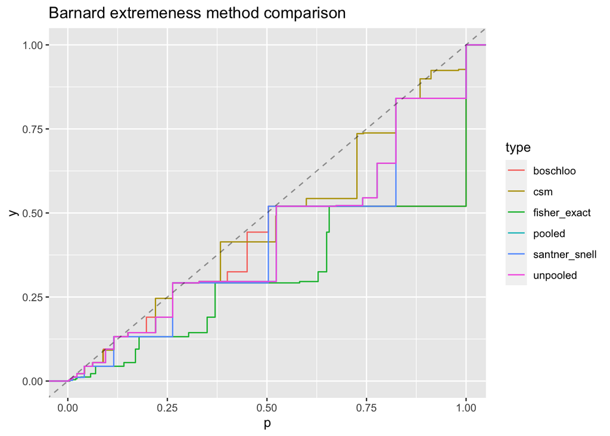

```r
set.seed(1)
foo <- rbinom_table(1000, row_n = c(10, 10), p = c(.5, .5)) # null is no association

# z pooled (score)
barnard_pooled <- apply(foo, MARGIN = 3,
                        FUN = function (x) {BarnardTest(x, method = "z-pooled")$p.value})

barnard_unpooled <- apply(foo, MARGIN = 3,
                        FUN = function (x) {BarnardTest(x, method = "z-unpooled")$p.value})

barnard_boschloo <- apply(foo,
                          MARGIN = 3,
                          FUN = function (x) {BarnardTest(x, method = "boschloo")$p.value})


barnard_csm <- apply(foo,
                          MARGIN = 3,
                          FUN = function (x) {BarnardTest(x, method = "csm")$p.value})

barnard_santner_snell <- apply(foo,
                               MARGIN = 3,
                               FUN = function (x) {BarnardTest(x, method = "santner and snell")$p.value})

# for reference
fisher_exact <-  apply(foo,
                               MARGIN = 3,
                               FUN = function (x) {fisher.test(x)$p.value})



# comment out any that you don't want to appear in the plot
barnard <- bind_cols(pooled = barnard_pooled,
                     unpooled = barnard_unpooled,
                     boschloo = barnard_boschloo,
                     csm = barnard_csm,
                     santner_snell = barnard_santner_snell,
                     fisher_exact = fisher_exact) %>%
  pivot_longer(everything(), names_to = "type", values_to = "p")

# there's some overplotting happening, dodge doesn't seem to work well for ecdf's
barnard %>% ggplot(aes(x = p, color = type)) +
  stat_ecdf()  +
  geom_abline(slope = 1, intercept = 0, color = "black", linetype = 2, alpha = .4) +
  labs(title = "Barnard extremeness method comparison")
```

For accuracy of the size of the test, it seems that csm is the most accurate, but also the most computationally intensive. We not that all the tests have more approriate “size” than the fisher_exact test.

Resources

- [Explanation of difference between unconditional and conditional](https://www.researchgate.net/publication/242179503_Conditional_versus_Unconditional_Exact_Tests_for_Comparing_Two_Binomials)
- [Exact Test Package Documentation](https://cran.r-project.org/web/packages/Exact/Exact.pdf) - `exact.test` function documentation has more information about barnard implmenetation.

## McNemar

McNemar tests are used when there is some “dichotomous trait”, for matched pairs. This means that the responses are statistically dependent. This is common for some longitudinal studies in which a single individual is asked two questions, and their answers are coded as locations in the table. Thus, the grand total, should be the number of pairs of data, not the total number of observations.

For example, suppose a person is asked if they voted democrat

```r
tribble(~"", ~"2008 democrat", ~"2008 republican",
        "2004 democrat", 175, 16,
        "2004 republican", 54, 188) %>%
  kbl()
```

|  | 2008 democrat | 2008 republican |
| --- | --- | --- |
| 2004 democrat | 175 | 16 |
| 2004 republican | 54 | 188 |

McNemar tests “Marginal Homogeneity”, meaning that the probabilities of the margins are the same. $p_a + p_b = p_a + p_c$ and $p_c + p_d = p_b + p_d$. Thus, this means that we are testing $H_0: p_b = p_c$, $H_A: p_b \neq p_c$. The score statistic is:

$$\begin{aligned}
z_0^2 = \frac{(b-c)^2}{b+c} \sim \chi^2_1
\end{aligned}$$

Variance is

$$\begin{aligned}
\hat\sigma_0 (d) = \frac{b + c}{N^2}
\end{aligned}$$

```r
# Presidential election, dependent table
pres <- matrix(c(175, 16,
                      54, 188),
                    ncol = 2,
                    byrow = TRUE)
pres_mcnemar <- mcnemar.test(pres, correct = FALSE)
# (54 - 16)^2 / (54 + 16) # 20.629
pres_mcnemar
```

```
##
##  McNemar's Chi-squared test
##
## data:  pres
## McNemar's chi-squared = 20.629, df = 1, p-value = 5.576e-06
```

Notes

A good reference is 11.1 in Categorical Data Analysis, 3rd edition by Agresti

## Breslow-Day Test

a test of homogeneity.

## CMH testing

The CMH testing is technically supposed to be done on tables in strata. the data type is an I X J X K, in which we have K strata and an I X J contingency table in each.

- you are not penalized for adding tables with sparse data with the CMH test statistic
- this reduces to the N-1 adjusted pearson chisquared statistic for 1 strata
- the test assumes that there is a common odds ratio to estimate, but in order to test the hypothesis we can use a Breslow-Day Test of Homogeneity
- Conditional logistic regression gives a similar answer, `clogit` in package `survival` because similar to cox model as well.

### CMH - McNemar Equivalence

```r
test <- matrix(c(5, 7, 3, 4), ncol = 2)
chisq.test(test, correct = FALSE)
```

```
##
##  Pearson's Chi-squared test
##
## data:  test
## X-squared = 0.0025703, df = 1, p-value = 0.9596
```

```r
0.0025703 / 19 * 18 # the "N-1" chisq statistic in a 2 x 2
```

```
## [1] 0.002435021
```

```r
foo <- array(c(5, 7, 3, 4,
               0, 0, 1, 1), dim = c(2, 2, 2))
mantelhaen.test(foo, correct = FALSE)
```

```
##
##  Mantel-Haenszel chi-squared test without continuity correction
##
## data:  foo
## Mantel-Haenszel X-squared = 0.0024351, df = 1, p-value = 0.9606
## alternative hypothesis: true common odds ratio is not equal to 1
## 95 percent confidence interval:
##  0.1444191 6.2805369
## sample estimates:
## common odds ratio
##          0.952381
```

```r
bar <- array(c(5, 7, 3, 4,
               0, 0, 1, 1,
               1, 6, 0, 0), dim = c(2, 2, 3))
mantelhaen.test(bar, correct = FALSE)
```

```
##
##  Mantel-Haenszel chi-squared test without continuity correction
##
## data:  bar
## Mantel-Haenszel X-squared = 0.0024351, df = 1, p-value = 0.9606
## alternative hypothesis: true common odds ratio is not equal to 1
## 95 percent confidence interval:
##  0.1444191 6.2805369
## sample estimates:
## common odds ratio
##          0.952381
```

```r
mantelhaen_2by2 <-  function(x) {
  mantelhaen.test(array(c(x, 0, 0, 1, 1), dim = c(2, 2, 2)), correct = FALSE)
}
```

## 2x2 tables Comparison

### Poisson Sampling

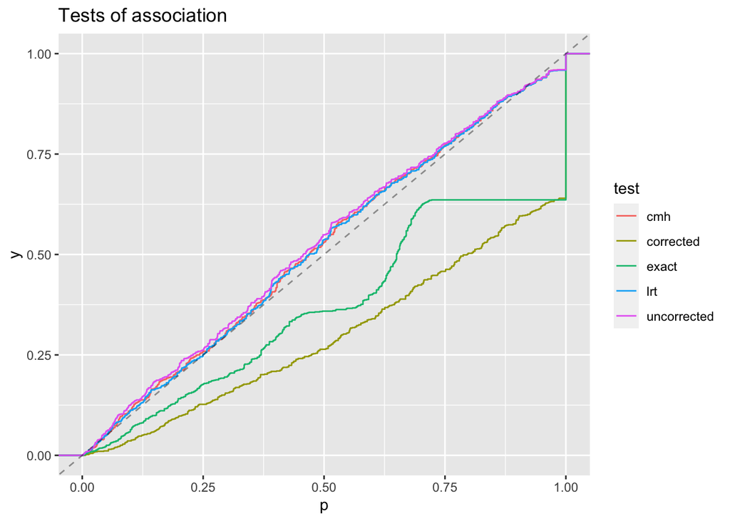

```r
# random poisson
foo <- rpoisson_table(num_tables = 1000, mean = 5, nrow = 2, ncol = 2)

# pearson uncorrected
pearson_uncorrected_p <-
  apply(foo,
      MARGIN = 3,
      function(x) {
        suppressWarnings(chisq.test(x, correct = FALSE))$p.value})

# pearson corrected
pearson_corrected_p <-
  apply(foo,
        MARGIN = 3,
        function(x) {
          suppressWarnings(chisq.test(x, correct = TRUE))$p.value})

fisher_exact_p <-
  apply(foo,
        MARGIN = 3,
        function(x) {
          suppressWarnings(fisher.test(x))$p.value})

# Pearson N-1 correction equivalent
cmh_p <-
  apply(foo,
        MARGIN = 3,
        function(x) {
          mantelhaen_2by2(x)$p.value
        })

# G-test (LRT)
lrt_p <-
  apply(foo,
        MARGIN = 3,
        function(x) {
          suppressWarnings(g.test(x))$p.value
        })


contingency_p <- bind_cols(uncorrected = pearson_uncorrected_p,
          corrected = pearson_corrected_p,
          exact = fisher_exact_p,
          cmh = cmh_p,
          lrt = lrt_p)

contingency_p %>%
  pivot_longer(everything(), names_to = "test", values_to = "p") %>%
  ggplot(aes(p, color = test)) +
  stat_ecdf(geom = "step") +
  geom_abline(slope = 1, intercept = 0, color = "black", linetype = 2, alpha = .4) +
  labs(title = "Tests of association") #+
```

```r
  coord_cartesian(xlim = c(0, .1), ylim = c(0, .1)) # for zooming in
```

[output not shown]

### Binomial Sampling

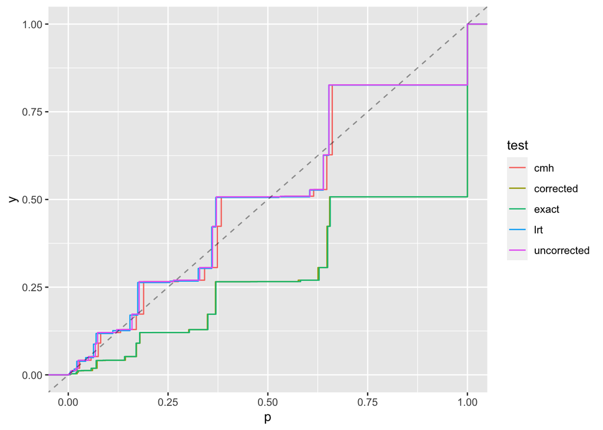

```r
foo <- rbinom_table(num_tables = 9000)

# pearson uncorrected
pearson_uncorrected_p <-
  apply(foo,
      MARGIN = 3,
      function(x) {
        suppressWarnings(chisq.test(x, correct = FALSE))$p.value})

# pearson corrected
pearson_corrected_p <-
  apply(foo,
        MARGIN = 3,
        function(x) {
          suppressWarnings(chisq.test(x, correct = TRUE))$p.value})

fisher_exact_p <-
  apply(foo,
        MARGIN = 3,
        function(x) {
          suppressWarnings(fisher.test(x))$p.value})

# Pearson N-1 correction equivalent
cmh_p <-
  apply(foo,
        MARGIN = 3,
        function(x) {
          mantelhaen_2by2(x)$p.value
        })

# G-test (LRT)
lrt_p <-
  apply(foo,
        MARGIN = 3,
        function(x) {
          suppressWarnings(g.test(x))$p.value
        })


contingency_p <- bind_cols(uncorrected = pearson_uncorrected_p,
          corrected = pearson_corrected_p,
          exact = fisher_exact_p,
          cmh = cmh_p,
          lrt = lrt_p)

contingency_p %>%
  pivot_longer(everything(), names_to = "test", values_to = "p") %>%
  ggplot(aes(p, color = test)) +
  stat_ecdf(geom = "step") +
  geom_abline(slope = 1, intercept = 0, color = "black", linetype = 2, alpha = .4) #+
```

```r
  coord_cartesian(xlim = c(0, .1), ylim = c(0, .1)) # for zooming in
```

[output not shown]

### Multinomial Sampling

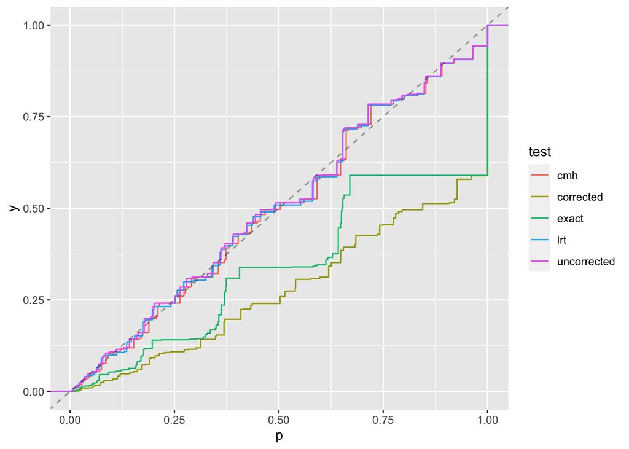

```r
foo <- rmultinom_table(num_tables = 1000)

# pearson uncorrected
pearson_uncorrected_p <-
  apply(foo,
      MARGIN = 3,
      function(x) {
        suppressWarnings(chisq.test(x, correct = FALSE))$p.value})

# pearson corrected
pearson_corrected_p <-
  apply(foo,
        MARGIN = 3,
        function(x) {
          suppressWarnings(chisq.test(x, correct = TRUE))$p.value})

fisher_exact_p <-
  apply(foo,
        MARGIN = 3,
        function(x) {
          suppressWarnings(fisher.test(x))$p.value})

# Pearson N-1 correction equivalent
cmh_p <-
  apply(foo,
        MARGIN = 3,
        function(x) {
          mantelhaen_2by2(x)$p.value
        })

# G-test (LRT)
lrt_p <-
  apply(foo,
        MARGIN = 3,
        function(x) {
          suppressWarnings(g.test(x))$p.value
        })


contingency_p <- bind_cols(uncorrected = pearson_uncorrected_p,
          corrected = pearson_corrected_p,
          exact = fisher_exact_p,
          cmh = cmh_p,
          lrt = lrt_p)

contingency_p %>%
  pivot_longer(everything(), names_to = "test", values_to = "p") %>%
  ggplot(aes(p, color = test)) +
  stat_ecdf(geom = "step") +
  geom_abline(slope = 1, intercept = 0, color = "black", linetype = 2, alpha = .4) #+
```

```r
  coord_cartesian(xlim = c(0, .1), ylim = c(0, .1)) # for zooming in
```

[output not shown]

### Hypergeometric Sampling

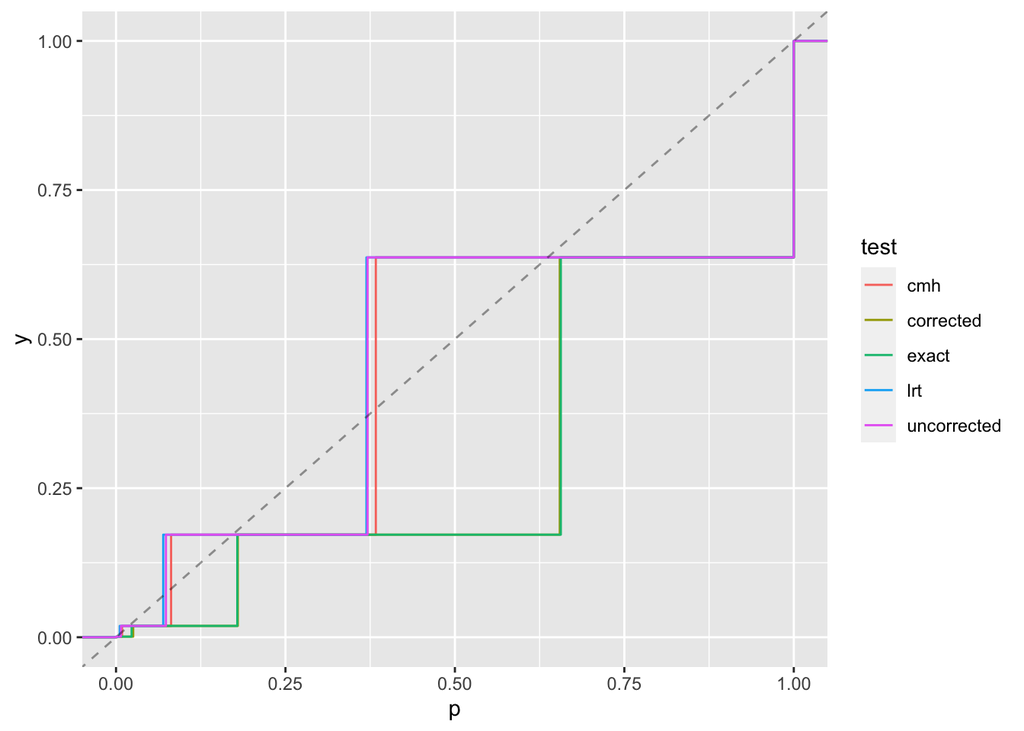

```r
foo <- rhyper_table(num_tables = 1000)

# pearson uncorrected
pearson_uncorrected_p <-
  apply(foo,
      MARGIN = 3,
      function(x) {
        suppressWarnings(chisq.test(x, correct = FALSE))$p.value})

# pearson corrected
pearson_corrected_p <-
  apply(foo,
        MARGIN = 3,
        function(x) {
          suppressWarnings(chisq.test(x, correct = TRUE))$p.value})

fisher_exact_p <-
  apply(foo,
        MARGIN = 3,
        function(x) {
          suppressWarnings(fisher.test(x))$p.value})

# Pearson N-1 correction equivalent
cmh_p <-
  apply(foo,
        MARGIN = 3,
        function(x) {
          mantelhaen_2by2(x)$p.value
        })

# G-test (LRT)
lrt_p <-
  apply(foo,
        MARGIN = 3,
        function(x) {
          suppressWarnings(g.test(x))$p.value
        })


contingency_p <- bind_cols(uncorrected = pearson_uncorrected_p,
          corrected = pearson_corrected_p,
          exact = fisher_exact_p,
          cmh = cmh_p,
          lrt = lrt_p)

contingency_p %>%
  pivot_longer(everything(), names_to = "test", values_to = "p") %>%
  ggplot(aes(p, color = test)) +
  stat_ecdf(geom = "step") +
  geom_abline(slope = 1, intercept = 0, color = "black", linetype = 2, alpha = .4) #+
```

```r
  coord_cartesian(xlim = c(0, .1), ylim = c(0, .1)) # for zooming in
```

[output not shown]